# How to predict consumptions of the building

# In the first part we have as usual the construction of the dataframe with the informations about a building that we need

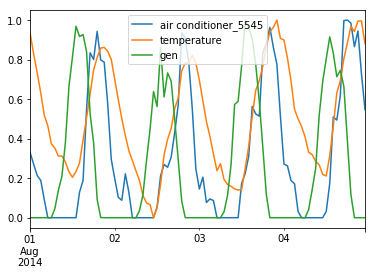

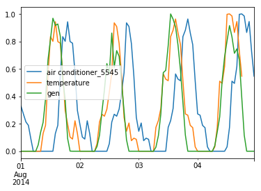

```
temperature-1hr
temperature-2hr
temperature-3hr
temperature-4hr
temperature-5hr
temperature-6hr
AC_Consumption-1hr
AC_Consumption-2hr
AC_Consumption-3hr
AC_Consumption-4hr
AC_Consumption-5hr
AC_Consumption-6hr
AC_Consumption-7hr
AC_Consumption-8hr
AC_Consumption-9hr
AC_Consumption-10hr
AC_Consumption-11hr
AC_Consumption-12hr
AC_Consumption-13hr
AC_Consumption-14hr
AC_Consumption-15hr
AC_Consumption-16hr
AC_Consumption-17hr
AC_Consumption-18hr
AC_Consumption-19hr
AC_Consumption-20hr
AC_Consumption-21hr
AC_Consumption-22hr
AC_Consumption-23hr
AC_Consumption-24hr
irradiance-3hr
irradiance-4hr
irradiance-5hr
irradiance-6hr
```

```python
# -*- coding: utf-8 -*-
#In this file I want to create a table with the information needed in order to predict the consumption of a builiding

#For first i need to import the external file with the information about consumption, irradiance and temperature of the building location
import pandas as pd
import numpy as np
import matplotlib.pyplot as plt
import os
# importing the external files
ExternalFilesFolder=r"C:\Users\Alessia\Documents\Primo_anno_en\Building\python4ScientificComputing_Numpy_Pandas_MATPLotLIB\ExternalFiles"
ConsumptionFileName= "consumption_5545.csv"
TemperatureFileName= "Austin_weather_2014.csv"
IrradianceFileName= "irradiance_2014_gen.csv"
path_consumptionFile = os.path.join(ExternalFilesFolder,ConsumptionFileName)
path_TemperatureFile = os.path.join(ExternalFilesFolder,TemperatureFileName)
path_IrradianceFile = os.path.join(ExternalFilesFolder,IrradianceFileName)

#dataframe consumption
DF_consumption = pd.read_csv(path_consumptionFile,sep=",", index_col=0)

PreviousIndex = DF_consumption.index
NewParsedIndex= pd.to_datetime(PreviousIndex)
DF_consumption.index =NewParsedIndex
DF_consumption_someDaysInJuly=DF_consumption["2014-07-01 00:00:00":"2014-07-03 23:00:00"]


# LEt's import the weather data

DF_weather = pd.read_csv(path_TemperatureFile,sep=";",index_col=0)
previousIndex_weather=DF_weather.index
newIndex_weather=pd.to_datetime(previousIndex_weather)
DF_weather.index = newIndex_weather
DF_weather.columns
Series_Temperature = DF_weather["temperature"]
DF_Temperature= DF_weather[["temperature"]]
DF_Temperature_someDaysInJuly=DF_Temperature["2014-07-01 00:00:00":"2014-07-03 23:00:00"]
#irradiance data

DF_irradianceSource = pd.read_csv(path_IrradianceFile,sep=";",index_col=1)
DF_irradiance=DF_irradianceSource[["gen"]]
DF_irradiance[DF_irradiance["gen"]<0] = 0
previousIndex_irradiance=DF_irradiance.index
newIndex_irradiance=pd.to_datetime(previousIndex_irradiance)
DF_irradiance.index = newIndex_irradiance
DF_irradiance_someDaysInJuly=DF_irradiance["2014-07-01 00:00:00":"2014-07-03 23:00:00"]


#So, I can create a table with these information

DF_joined = DF_consumption.join([DF_Temperature,DF_irradiance])

# Now,we should "clean" the table ,replacing the "none" with zero value
DF_joined_cleaned = DF_joined.dropna()
DF_joined_cleaned_copy=DF_joined_cleaned.copy()

#consider a dataframe related only same day
DF_joined_cleaned_chosenDates=DF_joined_cleaned_copy["2014-08-01 ":"2014-08-04 "]

#zero instead of none
DF_joined_cleaned_chosenDates.dropna()
DF_joined_cleaned_chosenDates.head()
DF_joined_cleaned_chosenDates.describe()
#plot after normalizing the dates
DF_joined_cleaned_chosenDates_min=DF_joined_cleaned_chosenDates.min()
DF_joined_cleaned_chosenDates_max=DF_joined_cleaned_chosenDates.max()
DF_joined_cleaned_chosenDates_normalized= (DF_joined_cleaned_chosenDates-DF_joined_cleaned_chosenDates_min)/(DF_joined_cleaned_chosenDates_max-DF_joined_cleaned_chosenDates_min)
plt.figure()
DF_joined_cleaned_chosenDates_normalized.plot()
plt.show()

# solve the problem of the  timezone
DF_joined_cleaned_chosenDates["temperature"]=DF_joined_cleaned_chosenDates.shift(-5)
DF_joined_cleaned_chosenDates.dropna()

DF_joined_cleaned_chosenDates_min=DF_joined_cleaned_chosenDates.min()
DF_joined_cleaned_chosenDates_max=DF_joined_cleaned_chosenDates.max()
DF_joined_cleaned_chosenDates_norm=(DF_joined_cleaned_chosenDates-DF_joined_cleaned_chosenDates_min)/(DF_joined_cleaned_chosenDates_max-DF_joined_cleaned_chosenDates_min)
plt.figure()
DF_joined_cleaned_chosenDates_norm.plot()
plt.show()


#creating lagged features
#first let me reconstruct my dataframe by applying time zone to the whole dataset

DF_joined=DF_consumption.join([DF_Temperature,DF_irradiance])
DF_mod=DF_joined.copy()
#for first we nust consider tho Austin hour
DF_mod["temperature"]=DF_mod["temperature"].shift(-5)
DF_mod.dropna(inplace=True)   # It is the same as writing it like this: DF_mod=DF_mod.dropna()
# In order to consider the time-lags we will need to include
# all of these columns with lags (shifts)DF_mod.head()
DF_mod.head()
DF_mod.describe()

#to consider the time lags we need to include all of there columns with lags(shifts)

DF_mod["Temperature-1h"]=DF_mod["temperature"].shift(1)
DF_mod["Temperature-2h"]=DF_mod["temperature"].shift(2)
DF_mod["Temperature-3h"]=DF_mod["temperature"].shift(3)
DF_mod["Temperature-4h"]=DF_mod["temperature"].shift(4)
DF_mod["Temperature-5h"]=DF_mod["temperature"].shift(5)
DF_mod.head()

#instead of use shift comand for every line of temperature tht we need we can use a faster metod
#we can write a cycle for that write a new column for every operation of shift made

#we introduce first the initial and final values of interval of time lag needed
lag_start=1
lag_end=6
lag_interval=1

column_name="temperature"
df=DF_mod


#then we can inser this cycle in a function called lag_feature in order to apply at our case DF_mod

def lag_feature(df,column_name,lag_start,lag_end,lag_interval):
    for i in range(lag_start,lag_end+1,lag_interval):
        new_column_name=column_name+"-"+str(i)+"hr"
        print new_column_name
        df[new_column_name]=df[column_name].shift(i)
        df.dropna(inplace=True)
    return df

DF_mod=lag_feature(DF_mod,"temperature",1,6,1)

DF_mod.head()

# we can change the names of irradiance and consumption columns
# in two ways:

#DF_mod.columns =["AC_consumption","temperature","irradiance"]
# or in this way:



DF_mod=DF_mod.rename(columns={"air conditioner_5545":"AC_Consumption","gen":"irradiance"} )
#now we need a time lag also for irradiance and consumption so
# Let's do the same

# Let's add the previous consumptions in the last 24 hours!
DF_mod=lag_feature(DF_mod,"AC_Consumption",1,24,1)

# Let's lag the irradiance for 3 to 6 hours

DF_mod=lag_feature(DF_mod,"irradiance",3,6,1)
DF_mod.head()
#let's see how many columns there are in final table
DF_mod.describe()


#Add seasonality parameter(time related)
#For first we add a column for hour
DF_mod["hour"]=DF_mod.index.hour
DF_mod["hour"].head()
#and then two columns for hour
DF_mod["sin_hour"]=np.sin(DF_mod.index.hour*2*np.pi/24)
DF_mod["cos_hour"]=np.cos(DF_mod.index.hour*2*np.pi/24)
#a column related to day
DF_mod["day_of_week"]=DF_mod.index.week
DF_mod[["hour","sin_hour","cos_hour"]].head(24)
#a column for month
DF_mod["month"]=DF_mod.index.month
#a column for the number of week
DF_mod["week_of_year"]=DF_mod.index.week

#let's create a function in order to know if it's a weekend day or not and create a new column with this information
def WeekendDetector(day):
    if (day==5 or day==6):
        weekendLabel=1
    else:
        weekendLabel=0
    return weekendLabel

DF_mod["weekend"]=DF_mod["day_of_week"].apply(WeekendDetector)

#At the end we can create another function to konw if an hour it's a working hour or not,so if there are people inside
def DayDetector(hour):
    if (hour<19 and hour>=9):
        DayLabel=1
    else:
        DayLabel=0
    return DayLabel

DF_mod["workingTime"]=DF_mod["hour"].apply(DayDetector)

DF_mod[["workingTime","weekend"]].head(24)
DF_mod.head()
DF_mod.columns

DF_mod.corr() #find correlation between two columns
DF_mod=DF_mod["2014-03-01":"2014-09-30"]

DF_target=DF_mod["AC_Consumption"]
DF_features=DF_mod.drop("AC_Consumption",axis=1)
```

# In the second part I want to predict the consumptions of the building . To do this we can use the "machine learning" strategy, so we need to create a model for the computer so that it can predict the consumption with only the informations that we have.

## In order to do our prediction in machine learning, we need to create two sets of our datas:training and test(20% for test) ,we will fit our model on the train data in order to make predictions on test datas. The "training" set contains a known output and the model learns on this data in order to be generalized to other data later on. The "test" dataset will be used to test our model’s prediction on this set.

### So,for first we need to import "train_test_split" in order to split the datas in training and test data

```python
from sklearn.model_selection import train_test_split
X_train,X_test,Y_train,Y_test=train_test_split(DF_features,DF_target,test_size=0.2,random_state=41234)
X_test.describe()
X_train.describe()
```

|  | temperature | irradiance | Temperature-1h | Temperature-2h | Temperature-3h | Temperature-4h | Temperature-5h | temperature-1hr | temperature-2hr | temperature-3hr | ... | irradiance-5hr | irradiance-6hr | hour | sin_hour | cos_hour | day_of_week | month | week_of_year | weekend | workingTime |
| --- | --- | --- | --- | --- | --- | --- | --- | --- | --- | --- | --- | --- | --- | --- | --- | --- | --- | --- | --- | --- | --- |
| count | 4104.000000 | 4104.000000 | 4104.000000 | 4104.000000 | 4104.000000 | 4104.000000 | 4104.000000 | 4104.000000 | 4104.000000 | 4104.000000 | ... | 4104.000000 | 4104.000000 | 4104.000000 | 4.104000e+03 | 4.104000e+03 | 4104.000000 | 4104.000000 | 4104.000000 | 4104.0 | 4104.000000 |
| mean | 75.359035 | 1.084325 | 75.362466 | 75.351060 | 75.349286 | 75.352578 | 75.361701 | 75.362466 | 75.351060 | 75.349286 | ... | 1.077513 | 1.079051 | 11.438840 | 5.651111e-03 | 2.348076e-03 | 24.624756 | 6.021686 | 24.624756 | 0.0 | 0.414230 |
| std | 12.898836 | 1.465994 | 12.894407 | 12.894559 | 12.878315 | 12.860320 | 12.856021 | 12.894407 | 12.894559 | 12.878315 | ... | 1.466541 | 1.465282 | 6.932962 | 7.054490e-01 | 7.089062e-01 | 8.854142 | 2.004326 | 8.854142 | 0.0 | 0.492649 |
| min | 22.920000 | 0.000000 | 23.240000 | 22.920000 | 22.920000 | 22.920000 | 22.920000 | 23.240000 | 22.920000 | 22.920000 | ... | 0.000000 | 0.000000 | 0.000000 | -1.000000e+00 | -1.000000e+00 | 9.000000 | 3.000000 | 9.000000 | 0.0 | 0.000000 |
| 25% | 68.810000 | 0.000000 | 68.880000 | 68.897500 | 68.907500 | 68.932500 | 69.040000 | 68.880000 | 68.897500 | 68.907500 | ... | 0.000000 | 0.000000 | 5.000000 | -7.071068e-01 | -7.071068e-01 | 17.000000 | 4.000000 | 17.000000 | 0.0 | 0.000000 |
| 50% | 76.780000 | 0.108883 | 76.845000 | 76.760000 | 76.770000 | 76.735000 | 76.710000 | 76.845000 | 76.760000 | 76.770000 | ... | 0.094417 | 0.102433 | 11.000000 | 1.224647e-16 | 6.123234e-17 | 25.000000 | 6.000000 | 25.000000 | 0.0 | 0.000000 |
| 75% | 84.150000 | 2.180758 | 84.122500 | 84.132500 | 84.092500 | 84.142500 | 84.082500 | 84.122500 | 84.132500 | 84.092500 | ... | 2.074283 | 2.150017 | 17.000000 | 7.071068e-01 | 7.071068e-01 | 32.000000 | 8.000000 | 32.000000 | 0.0 | 1.000000 |
| max | 101.050000 | 5.099667 | 101.050000 | 101.050000 | 101.050000 | 101.050000 | 101.050000 | 101.050000 | 101.050000 | 101.050000 | ... | 5.080083 | 5.099667 | 23.000000 | 1.000000e+00 | 1.000000e+00 | 40.000000 | 9.000000 | 40.000000 | 0.0 | 1.000000 |

8 rows × 49 columns

## 1_The first model that I want to use in order to do our prediction using the split datas is the linear regression ,so we need to import this

```python
from sklearn import linear_model
linear_reg=linear_model.LinearRegression()
```

## the second step will be fitting the model on train datas

```python
linear_reg.fit(X_train,Y_train)
```

```
LinearRegression(copy_X=True, fit_intercept=True, n_jobs=1, normalize=False)
```

## and then I want to create a prediction on test datas. To see this in my dataframe I create a new column called"AC_cons_predicted_linearReg_split" with these values

```python
predicted_linearReg_split=linear_reg.predict(X_test)
predicted_DF_linearReg_split=pd.DataFrame(predicted_linearReg_split,index=Y_test.index,columns=["AC_cons_predicted_linearReg_split"])
predicted_DF_linearReg_split=predicted_DF_linearReg_split.join(Y_test)
```

## we can see on a graph the real and predicted values related to only a period of time in august

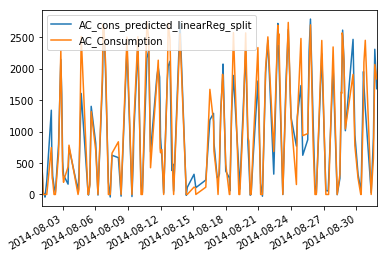

[figure not shown]

```python
predicted_DF_linearReg_split_august=predicted_DF_linearReg_split["2014-08-01":"2014-08-31"]
predicted_DF_linearReg_split_august.plot()
plt.show()
```

## Now we want calculate how accurate our predictions are. So we import the functions to estimate the error

```python
from sklearn.metrics import mean_absolute_error,mean_squared_error,r2_score
MAE_linearReg_split=mean_absolute_error(predicted_linearReg_split,Y_test)
MSE_linearReg_split=mean_squared_error(predicted_linearReg_split,Y_test)
R2_linearReg_split=r2_score(predicted_linearReg_split,Y_test)
```

```python
R2_linearReg_split
```

```
0.87523728702811254
```

### With this first model I’ve loaded in the data, split it into a training and testing sets,fitted a regression model to the training data,made predictions based on this data and tested the predictions on the test data but what if the split we make isn’t random? The second way of doing this is using k-fold cross validation instead of 2 subsets,we create k subsets, and train on k-1 one of those subset and leave the last subset (or the last fold) as test data

### For first we need to import the model "cross validation"

```python
from sklearn.model_selection import cross_val_predict
```

### then we choose 10 cross validtion in order to create our model

```python
predict_DF_linearReg_CV=cross_val_predict(linear_reg,DF_features,DF_target,cv=10)
```

### as before i add a column with these values called"AC_cons_predicted_linearReg_CV"

```python
predicted_DF_linearReg_CV=pd.DataFrame(predict_DF_linearReg_CV,index=DF_target.index,columns=["AC_cons_predicted_linearReg_CV"])
predicted_DF_linearReg_CV=predicted_DF_linearReg_CV.join(DF_target)
```

### we can see the plot of our prediction related to our period of time

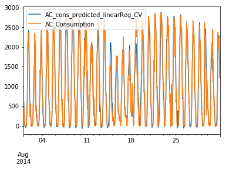

```python
predicted_DF_linearReg_CV_august=predicted_DF_linearReg_CV["2014-08-01":"2014-08-31"]
predicted_DF_linearReg_CV_august.plot()
plt.show()
```

### now we can evaluate our prediction

```python
MAE_linearReg_CV=mean_absolute_error(predict_DF_linearReg_CV,DF_target)
MSE_linearReg_CV=mean_squared_error(predict_DF_linearReg_CV,DF_target)
R2_linearReg_CV=r2_score(predict_DF_linearReg_CV,DF_target)
```

```python
R2_linearReg_CV
```

```
0.87818882238530838
```

## Another algorithm is "random forest regressor" in this way we use more little range. The model learns any relationships between the data (known as features in machine learning) and the values we want to predict (called the target). When we ask the decision tree to make a prediction , we must give it the same data it used during training (the features) and it gives us an estimate based on the structure it has learned. The fundamental idea behind a random forest is to combine many decision trees into a single model.

### we need to import the model, create the new column in the dataframe"AC_cons_predicted_RF_CV" with the values in DF_target

```python
from sklearn.ensemble import RandomForestRegressor
reg_RF=RandomForestRegressor()

predict_RF_CV=cross_val_predict(reg_RF,DF_features,DF_target,cv=10)
predicted_DF_RF_CV=pd.DataFrame(predict_RF_CV,index=DF_target.index,columns=["AC_cons_predicted_RF_CV"])
predicted_DF_RF_CV=predicted_DF_RF_CV.join(DF_target)
```

### again we can plot

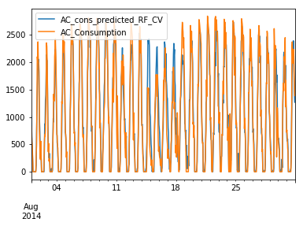

```python
predicted_DF_RF_CV_august=predicted_DF_RF_CV["2014-08-01":"2014-08-31"]
predicted_DF_RF_CV_august.plot()
plt.show()
```

### the accuracy of estimate is

```python
MAE_RF_CV=mean_absolute_error(predict_RF_CV,DF_target)
MSE_RF_CV=mean_squared_error(predict_RF_CV,DF_target)
R2_RF_CV=r2_score(predict_RF_CV,DF_target)
```

```python
R2_RF_CV
```

```
0.90237846577065739
```

## In the end we use another method. It's called online learning and in this way we use only a part of datas,is an approach that ingests data one observation at a time.

```python
DF_onlineConsumptionPrediction=pd.DataFrame(index=DF_mod.index)
```

### We choose a dataframe for the period of training called "period_of_training".

### There are two chances for the while cycle:a cycle with linear regression method and another one with random forest

### We can use random forest because is more accurate. Infact it's possible to see this in the final result.

```python
period_of_training=pd.Timedelta(30,unit="d")

FirstTimeStamp_measured=DF_mod.index[0] #first hour of considered period
LastTimeStamp_measured=DF_mod.index[-1]  #last hour of considered period

FirstTimeStamp_toPredict=FirstTimeStamp_measured+period_of_training #the first next hour after period of training

training_startTimeStamp=FirstTimeStamp_measured
training_endTimeStamp=FirstTimeStamp_toPredict
timeStamp_toPredict=FirstTimeStamp_toPredict   #first hour predicted
DF_onlineConsumptionPrediction=DF_onlineConsumptionPrediction.truncate(before=training_endTimeStamp)
#we create a cycle that allows us to update
while (timeStamp_toPredict< LastTimeStamp_measured):

    #DF_feature_train=DF_features.loc[training_startTimeStamp:training_endTimeStamp]
    DF_feature_train=DF_features.truncate(before=training_startTimeStamp,after=training_endTimeStamp)
    DF_target_train=DF_target.truncate(before=training_startTimeStamp,after=training_endTimeStamp)

    DF_feature_test=DF_features.loc[timeStamp_toPredict].values.reshape(1,-1)
    DF_target_test=DF_target.loc[timeStamp_toPredict]

    reg_RF.fit(DF_feature_train,DF_target_train)  #reg_RF instead of linear_reg
    predicted_Consumption=reg_RF.predict(DF_feature_test)
    DF_onlineConsumptionPrediction.loc[timeStamp_toPredict,"Predicted"]=predicted_Consumption
    DF_onlineConsumptionPrediction.loc[timeStamp_toPredict,"Real"]=DF_target_test


    timeStamp_toPredict=timeStamp_toPredict+pd.Timedelta(1,unit="h")
    training_endTimeStamp=training_endTimeStamp+pd.Timedelta(1,unit="h")
    training_startTimeStamp=training_startTimeStamp+pd.Timedelta(1,unit="h")
```

### the estimation is done as usual

```python
DF_onlineConsumptionPrediction.dropna(inplace=True)
R2_score_online_linearReg=r2_score(DF_onlineConsumptionPrediction[["Real"]],DF_onlineConsumptionPrediction[["Predicted"]])
```

```python
R2_score_online_linearReg
```

```
0.98082452941905207
```

## At the end,we can see that the better method is the last one, becuase the"R2"value is very close to 1 but the time of computation is higher than the others.